# Why AIC doesn’t do what you think and what can be done about it

October 25 2016

## On inference after model selection

*In a world with a large number of unrelated variables and no clear a priori specifications, uncritical use of standard methods will lead to models that **appear** to have a lot of explanatory power.*

Freedman, A Note on Screening Regression Equations, 1983

*There is an abundance of advice on how to perform the mechanics of choosing a model, …. There is a dearth of respectable theory, or even trustworthy advice, …*

Miller, Subset Selection in Regression, 1990

*This usage [ad hoc inference after model selection] has long been a quiet scandal in the statistical community.*

Breiman, The Little Bootstrap and Other Methods for Dimensionality Selection in Regression: X-Fixed Prediction Error, 1992

## On inference after model selection

*What has happened in this field since the first edition was published in 1990? The short answer is that there has been very little real progress.*

Miller, Subset Selection in Regression, Second Edition, 2000

*It [stepwise variable selection] … violates every principle of statistical estimation and hypothesis testing.*

Harrell, Regression Modeling Strategies, 2001

*Do not include test statistics and P-values when using the information-theoretic approach as this inappropriately mixes differing analysis paradigms.*

Burnham and Anderson, Model Selection and Multimodel Inference, 2002

*Currently, there is no overarching theory for inference after model selection.*

Efron and Hastie, Computer Age Statistical Inference, 2016

## First take home message

The following two-step procedure

- perform data driven model selection (e.g. minimize AIC)
- compute and report statistics **as if the model were not selected**

is wrong and can be grossly misleading.

Biased estimates, over-optimistic assessment of model fit and predictive ability, and under-estimation of uncertainty are some of the consequences.

**Don't use, promote or teach this two-step procedure!**

## AIC for Gaussian regression (fixed variance)

If \(Y \sim \mathcal{N}(\xi, \sigma^2 I)\) then \[\textrm{AIC} = ||Y - \hat{\xi}||^2 / \sigma^2 + 2 d\] when \(\sigma^2\) is fixed and \(\hat{\xi}\) is the least squares estimator in a subset of dimension \(d\).

Fix \(\sigma^2 = 1\) from hereon, and for \(\lambda \in \Lambda\) (and index set) let \[\textrm{AIC}(\lambda) = ||Y - \hat{\xi}(\lambda)||^2 + 2 d(\lambda).\]

Consider \(\xi = X \beta\) for \(X\) and \(n \times p\) matrix and \(\beta \in \mathbb{R}^p\).

## n = 25, p = 5

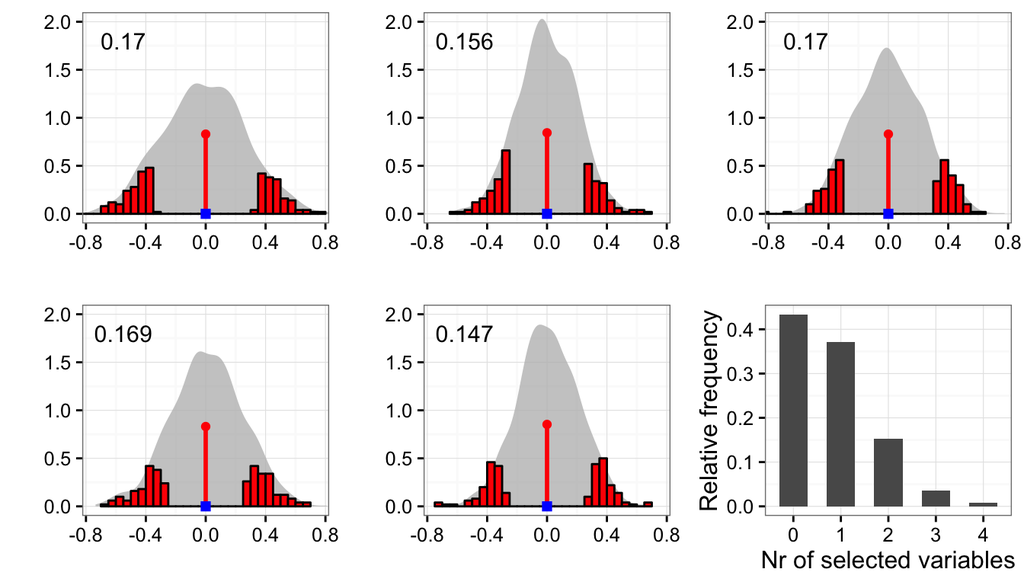

## n = 25, p = 20

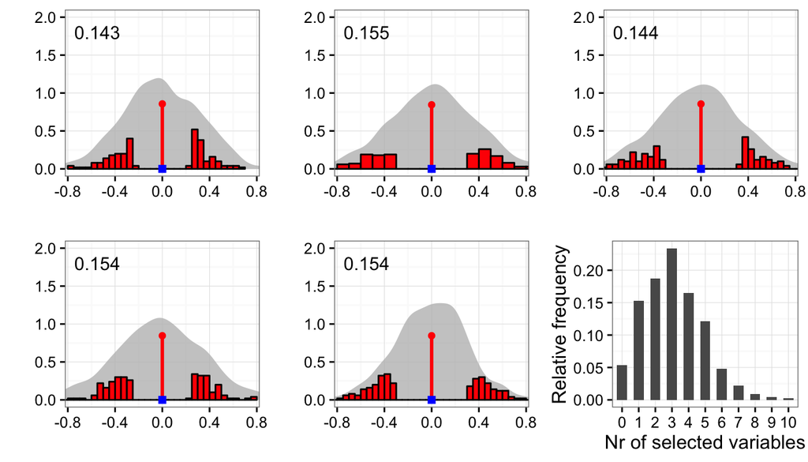

## n = 25, p = 5

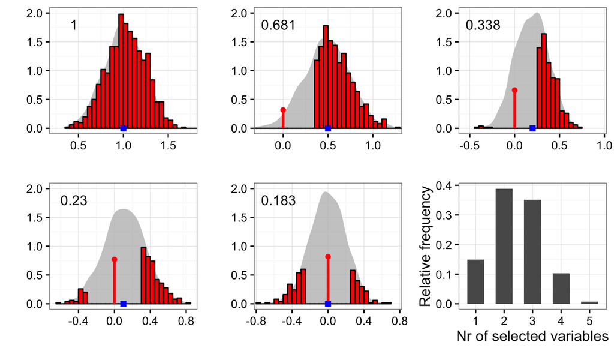

## n = 25, p = 20

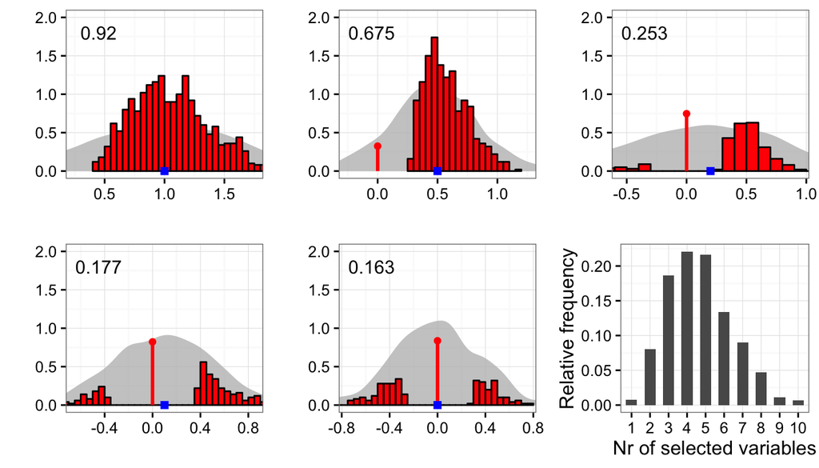

## Model weights and model averaging

Introduce weights \[w_{\gamma}(\lambda) = \frac{\exp(- \gamma \textrm{AIC}(\lambda))}{\int \exp(- \gamma \textrm{AIC}(\lambda)) \pi(\mathrm{d}\lambda)}.\]

- \(\gamma = 1/2\) has a Bayes interpretation
- \(\gamma \to 0\) gives all models the same weight
- \(\gamma \to \infty\) concentrates the weights on the models with minimal AIC.

\[\hat{\xi}_{\gamma} = \int \hat{\xi}(\lambda) w_{\gamma}(\lambda) \pi(\mathrm{d} \lambda)\] is the model averaging estimator.

## n = 25, p = 5, averaging

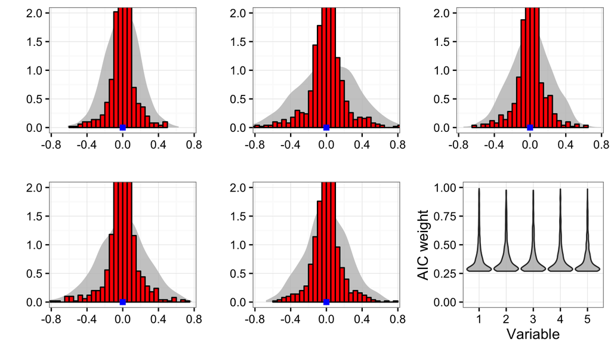

## n = 25, p = 20, averaging

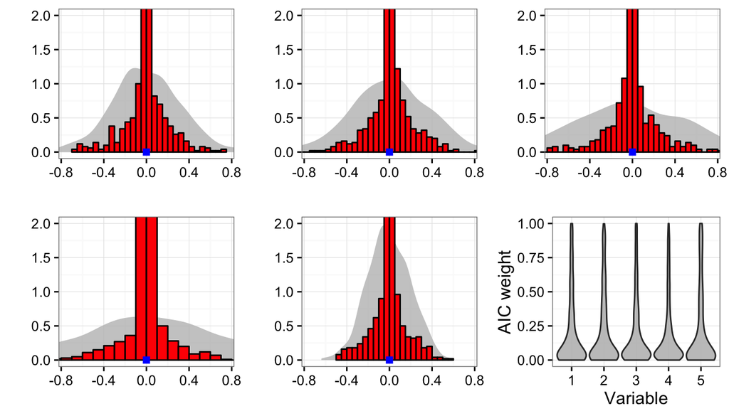

## n = 25, p = 5, averaging

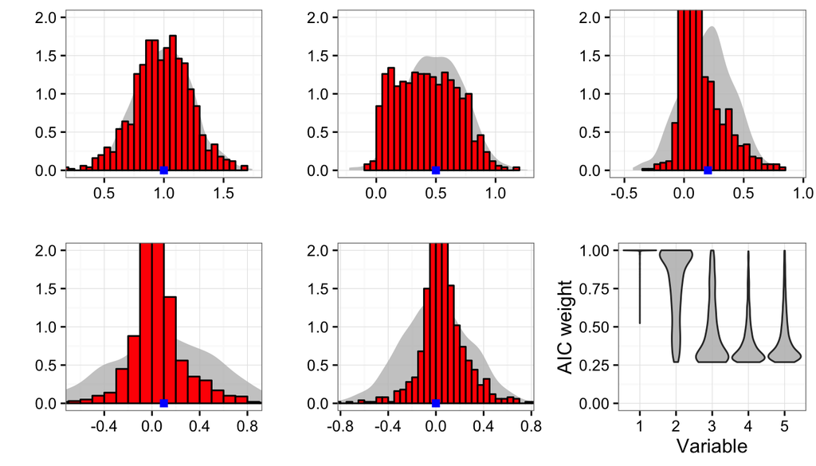

## n = 25, p = 20, averaging

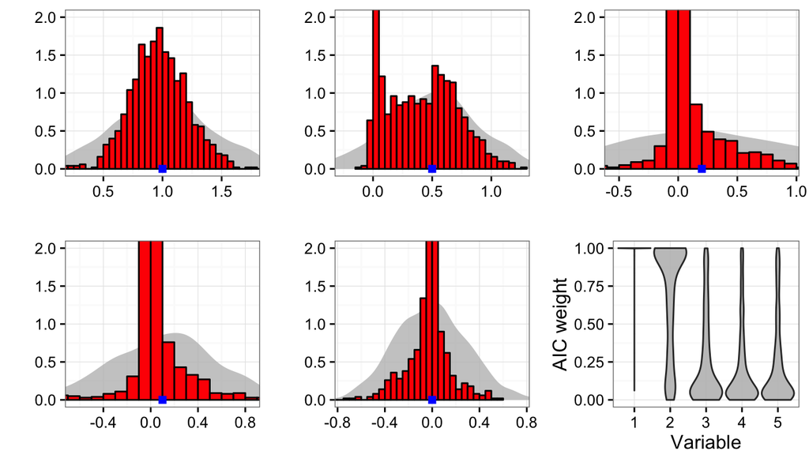

## Summary

Model selection estimators

- have highly non-Gaussian distributions, which are difficult to use for confidence intervals.
- are biased – conditionally on selection – unless the true effect is large.

Model averaging estimators

- reduce variance via shrinkage for small effects.
- have a distribution – though non-Gaussian – that can be used for confidence intervals (at least via bootstrapping).

## Second take home message

But isn't model selection based on AIC sensible?

*Regardless of asymptotic optimality results, criterion or estimates such as \(C_p\), AIC, BIC, and so on are highly biased in finite data situations because they do not account for the data-driven selection.*

Breiman, The Little Bootstrap and Other Methods for Dimensionality Selection in Regression: X-Fixed Prediction Error, 1992

AIC is a prediction error estimate for a **fixed model**.

**AIC doesn't adjust for model selection.**

## AIC as a prediction error estimate

Let \(Y \perp \!\! \perp Y^{\textrm{New}}\) and \(Y \overset{\mathcal{D}}{=} Y^{\textrm{New}}\).

If \(Y \sim (\xi, I)\), \(\hat{\xi}(\lambda) = S_{\lambda} Y\) and \(d(\lambda) = \mathrm{tr}(S_{\lambda})\) then \[E (\textrm{AIC}(\lambda)) = E || Y^{\mathrm{New}} - \hat{\xi}(\lambda)||^2 = n + \underbrace{E || \xi - \hat{\xi}(\lambda)||^2}_{\textrm{MSE}}.\]

Thus \[\textrm{AIC}(\lambda) - n = ||Y - S_{\lambda}Y||^2 + 2 d(\lambda) - n\] is an unbiased estimate of MSE.

## Forward stepwise variable selection

If \(S_{\lambda}\) is a **fixed** projection then \(d(\lambda) = \textrm{rank}(S_{\lambda})\).

Forward stepwise variable selection results in a sequence of projections \[S_{0}, \ldots, S_{p}\] onto nested subspaces.

The projection \(S_d\) includes the predictor not included by \(S_{d-1}\) that minimizes the residual squared error.

It follows that \(S_d\) is **selected in a data dependent way**.

## n = 100, p = 50

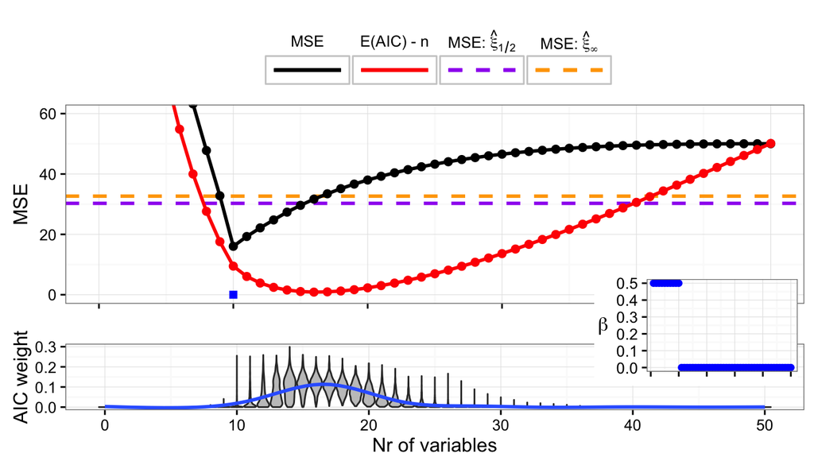

## n = 100, p = 50

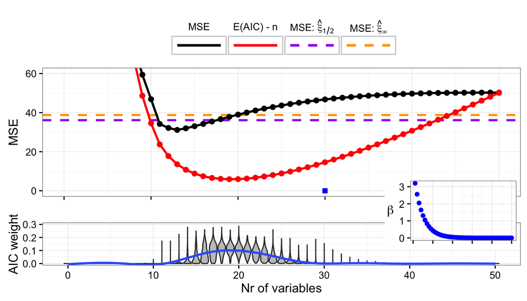

## n = 100, p = 50

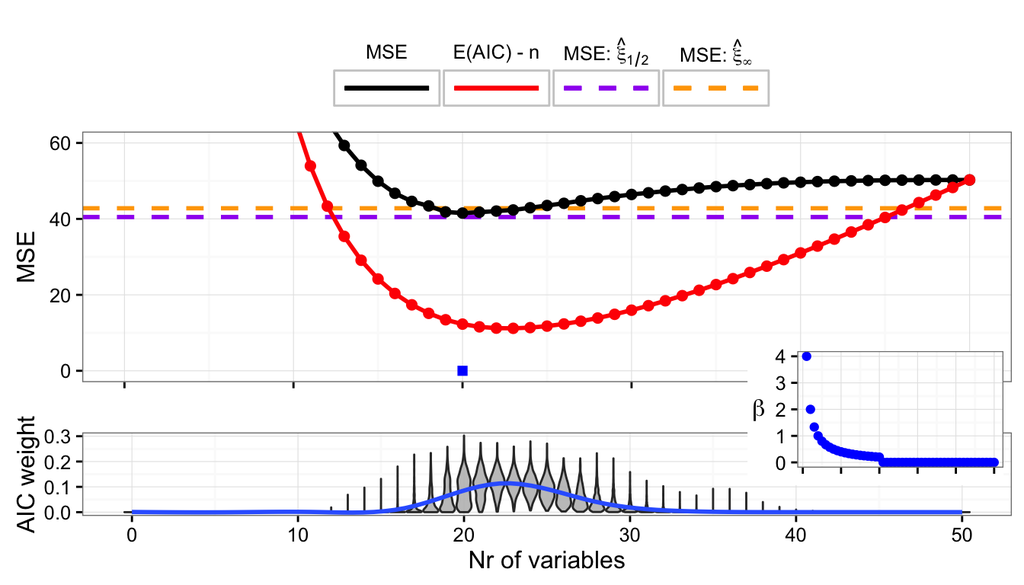

## Generalized information criteria

\[\textrm{IC} = ||Y - \hat{\xi}||^2 + c(d, n, p).\] **Akaike:** \(c(d, n, p) = 2 d.\)

**Bayes:** \(c(d, n, p) = \log(n) d.\)

**Hannan–Quinn:** \(c(d, n, p) = 2 \log(\log(n)) d\)

**Risk inflation:** \(c(d, n, p) = (2 \log(p)) d\)

We propose a new choice of \(c(d, n, p)\).

## Model selection

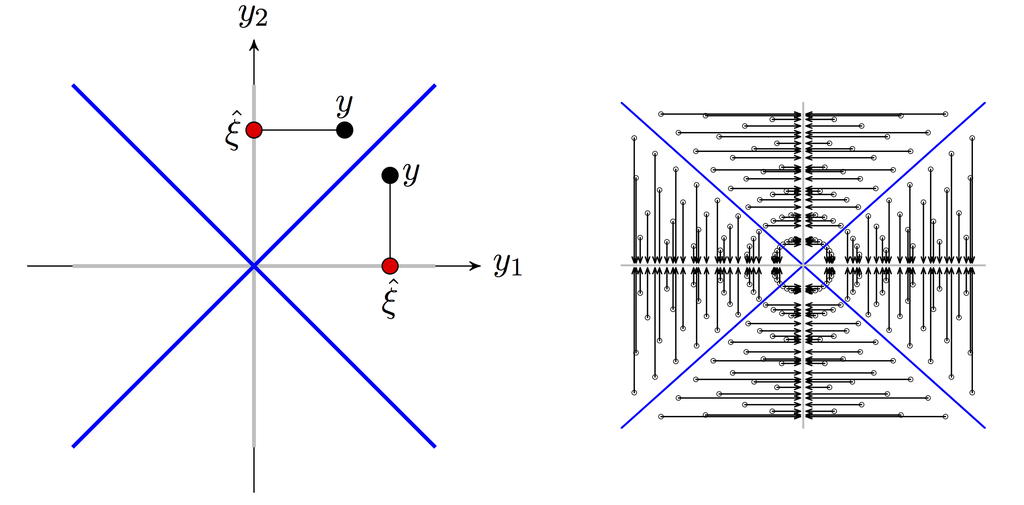

Model selection results in **nonlinear** and **discontinuous** estimators.

\[E || Y^{\mathrm{New}} - \hat{\xi}(\lambda)||^2 = E(\mathrm{AIC}(\lambda)) + 2 q \lambda \partial_{\lambda} E(d(\lambda)) + R\] for some model selection estimators. *Debiased lasso*: \(R = 0\) and \(q = 1\).

## Forward stepwise variable selection

Define for \(\lambda \geq 0\) \[ \DeclareMathOperator*{\argmin}{arg\,min} d(\lambda) = \argmin_{d = 0, \ldots, p} ||Y - S_d Y||^2 + \lambda d. \]

Then \(S_{d(\lambda)}\) has prediction error as above with \(q = 2\) and \(R \to 0\) for \(X \to \textrm{orthogonal design}.\)

It gives generalized information criterion and model average \[ \begin{aligned} \textrm{IC}(\lambda) & = ||Y - S_{d(\lambda)} Y||^2 + 2(d(\lambda) + 2 \hat{\partial}) \\ \tilde{\xi}_{\gamma} & = \frac{\int \hat{\xi}(\lambda) \exp(- \gamma \textrm{IC}(\lambda))\pi(\mathrm{d} \lambda)}{\int \exp(- \gamma \textrm{IC}(\lambda)) \pi(\mathrm{d}\lambda)} \end{aligned} \]

## n = 100, p = 50, \(\gamma = 0.1\)

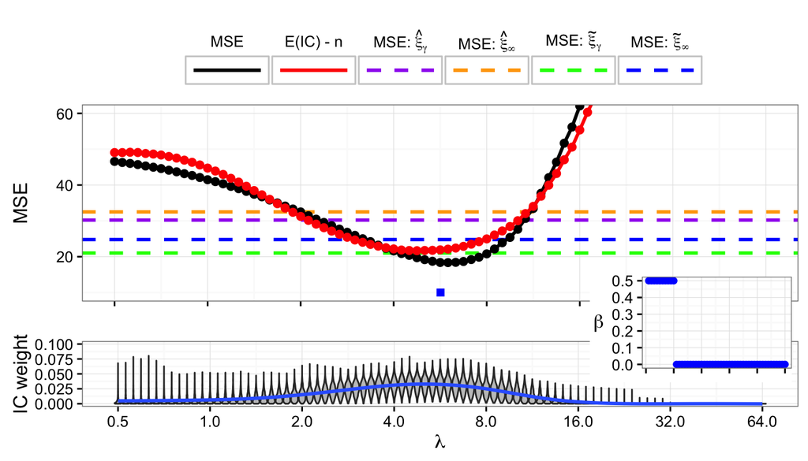

## n = 100, p = 50, \(\gamma = 0.1\)

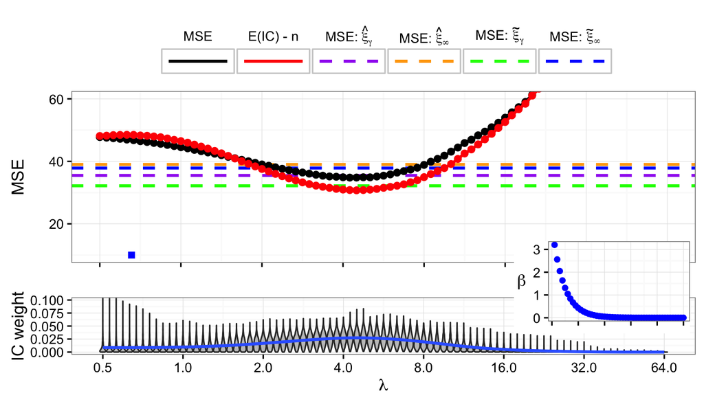

## n = 100, p = 50, \(\gamma = 0.1\)

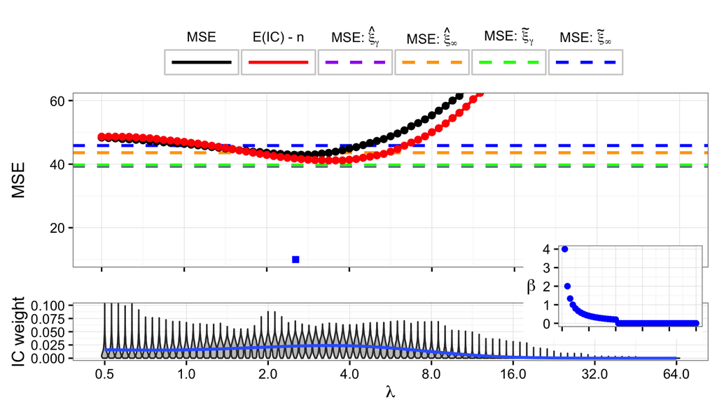

## Conclusion

Frederik Riis Mikkelsen and NRH. [Degrees of Freedom for Piecewise Lipschitz Estimators](https://arxiv.org/abs/1601.03524). arXiv:1601.03524

NRH and Alexander Sokol. [Degrees of freedom for nonlinear least squares estimation](https://arxiv.org/abs/1402.2997). arXiv:1402.2997

## Thanks

*Standard statistical practice ignores model uncertainty. Data analysts typically select a model from some class of models and then proceed as if the selected model had generated the data. This approach ignores the uncertainty in model selection, leading to over-confident inferences and decisions that are more risky than one thinks they are.*

Hoeting *et al.*, Bayesian Model Averaging: A Tutorial, 1999

**Let's do better!**

Source code: https://github.com/nielsrhansen/InformationCriteria